# **Assignment:** Classification of … using PCA, Clustering analysis, and ANOVA

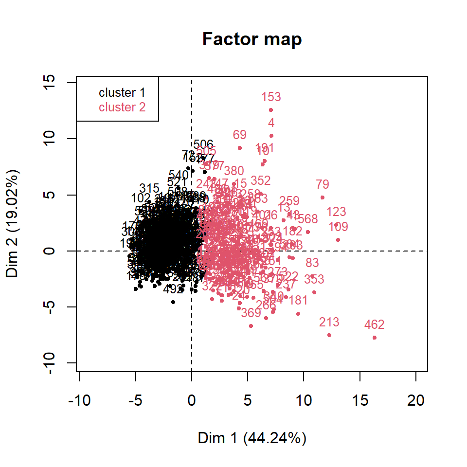

```r
plot.HCPC(res.hcpc,choice='map',draw.tree=FALSE,title='Factor map')
```

```r
res.hcpc$desc.var$quanti
```

```
## $`1`
##                             v.test Mean in category Overall mean sd in category
## symmetry_se              -2.381940     1.994771e-02 2.053135e-02   6.948020e-03
## fractal_dimension_mean   -4.222150     6.192077e-02 6.280458e-02   5.936044e-03
## fractal_dimension_se     -6.962302     3.250402e-03 3.796685e-03   2.110742e-03
## texture_mean             -8.136485     1.824393e+01 1.928040e+01   4.041460e+00
## texture_worst            -8.533234     2.411435e+01 2.566896e+01   5.686349e+00
## symmetry_worst          -10.035456     2.716681e-01 2.900808e-01   4.412183e-02
## smoothness_worst        -10.195669     1.255605e-01 1.324433e-01   1.980582e-02
## smoothness_mean         -10.231294     9.220641e-02 9.643727e-02   1.245037e-02
## symmetry_mean           -10.249214     1.728736e-01 1.812014e-01   2.324094e-02
## fractal_dimension_worst -10.440732     7.838005e-02 8.396968e-02   1.258000e-02
## concavity_se            -10.679362     2.239898e-02 3.194987e-02   1.733584e-02
## compactness_se          -11.656645     1.933140e-02 2.551479e-02   1.278953e-02
## concave_points_se       -13.026611     9.440873e-03 1.181690e-02   4.528762e-03
## area_se                 -13.548575     2.209945e+01 4.037438e+01   1.013949e+01
## radius_se               -14.422787     2.865921e-01 4.052063e-01   1.158245e-01
## perimeter_se            -14.448729     2.000276e+00 2.866619e+00   7.834008e-01
## compactness_worst       -15.959273     1.802282e-01 2.545992e-01   8.520753e-02
## area_mean               -16.173706     4.871960e+02 6.557234e+02   1.544061e+02
## radius_mean             -16.356902     1.243396e+01 1.413850e+01   1.942663e+00
## area_worst              -16.838783     5.976253e+02 8.816606e+02   2.041599e+02
## perimeter_mean          -16.907312     7.989815e+01 9.204658e+01   1.281463e+01
## compactness_mean        -17.134098     7.764306e-02 1.044479e-01   2.858810e-02
## radius_worst            -17.462766     1.378251e+01 1.628118e+01   2.300775e+00
## concavity_worst         -17.532394     1.643566e-01 2.726677e-01   1.134018e-01
## perimeter_worst         -17.898779     8.954142e+01 1.073459e+02   1.543926e+01
## concavity_mean          -19.130891     4.377573e-02 8.895565e-02   3.009071e-02
## concave_points_worst    -19.256934     7.736947e-02 1.148080e-01   3.739687e-02
## concave_points_mean     -19.555607     2.653310e-02 4.900527e-02   1.555627e-02
##                           Overall sd      p.value
## symmetry_se             8.262246e-03 1.722169e-02
## fractal_dimension_mean  7.058406e-03 2.419834e-05
## fractal_dimension_se    2.645730e-03 3.347563e-12
## texture_mean            4.295380e+00 4.069188e-16
## texture_worst           6.143097e+00 1.423123e-17
## symmetry_worst          6.186734e-02 1.064665e-23
## smoothness_worst        2.276286e-02 2.073129e-24
## smoothness_mean         1.394371e-02 1.435876e-24
## symmetry_mean           2.739805e-02 1.193092e-24
```

[output cut: 64 more lines]

```
## radius_se               2.773115e-01 3.720118e-47
## area_se                 4.548230e+01 8.078346e-42
## concave_points_se       6.150366e-03 8.635882e-39
## compactness_se          1.788683e-02 2.122420e-31
## concavity_se            3.015633e-02 1.271418e-26
## fractal_dimension_worst 1.805229e-02 1.615603e-25
## symmetry_mean           2.739805e-02 1.193092e-24
## smoothness_mean         1.394371e-02 1.435876e-24
## smoothness_worst        2.276286e-02 2.073129e-24
## symmetry_worst          6.186734e-02 1.064665e-23
## texture_worst           6.143097e+00 1.423123e-17
## texture_mean            4.295380e+00 4.069188e-16
## fractal_dimension_se    2.645730e-03 3.347563e-12
## fractal_dimension_mean  7.058406e-03 2.419834e-05
## symmetry_se             8.262246e-03 1.722169e-02
```

```r
res.hcpc$desc.axes$quanti
```

```
## $`1`
##         v.test Mean in category Overall mean sd in category Overall sd
## Dim.1 -20.2478        -2.187516 1.787498e-15       1.440264   3.642952
##           p.value
## Dim.1 3.71438e-91
##
## $`2`
##        v.test Mean in category Overall mean sd in category Overall sd
## Dim.1 20.2478         4.386606 1.787498e-15       2.624071   3.642952
##           p.value
## Dim.1 3.71438e-91
```

## **Analysis of Variance (ANOVA)**

Analysis of variance (ANOVA) is a statistical technique that allows us to test the null hypothesis that the means of any three or more groups are the same against the alternative hypothesis that they are not equal using information from their samples. The fundamental idea behind the ANOVA technique is to compare the degree of variation within each sample to the degree of variance between samples in order to determine whether the population means differ from one another. It is assumed that the samples used in the ANOVA model come from normal populations with similar variances. An ANOVA with a single factor between subjects is used when there is only one factor and the analysis has more than two levels and multiple subjects in both experimental conditions.

# **Result**

## **PCA and HC classification**

### HC interpretation

As a result of the cluster analysis, specific quantitative factors that identified the distinctive qualities and contributions of every cluster were found to exist. There are 2 cluster:

- Cluster 1 contains about 90% of B tumors and 10% of M tumors.
- Cluster 2 contains about 10% of B tumors and 90% of M tumors.

First of all, Cluster 1, which is composed of more than 90% of benign tumors, has characteristics by having almost all values quite lower when compare to overall. Cluster 1 type are distinguished by characteristics that stand out: symmetry, fractal dimension, texture, smoothness, concavity, compactness, concave points, area and so on.

Opposite to cluster 2, which consists primarily of malignant tumors, has unique characteristics that are indicated by increased almost all values relative to the dataset’s average values.

## **ANOVA test**

### **Hypothesis 1:** Mean of Concave Points between benign and malignant tumors.

- Null Hypothesis (H0): There is no significant difference in Mean of Concave Points between 2 tumor types.
- Alternative Hypothesis (H1): There is a significant difference in Mean of Concave Points between 2 tumor types.

#### Test:

ANOVA for Mean of Concave Points among tumor types.

```r
# ANOVA for Mean of Concave Points among tumor types.
h1 <- lm(
  concave_points_mean ~ as.factor(diagnosis),
  data = data
)
anova(h1)
```

|  | Df | Sum Sq | Mean Sq | F value | Pr(>F) |
| --- | --- | --- | --- | --- | --- |
| as.factor(diagnosis) | 1 | 0.5140712 | 0.5140711540 | 858.9431 | 1.435847e-115 |
| Residuals | 566 | 0.3387469 | 0.0005984927 | NA | NA |

#### Interpretation:

The ANOVA test indicates a highly significant difference in Mean of Concave Points among different tumor types (p = 2.2e-16 < 0.001). This suggests that Mean of Concave Points vary strongly between benign and malignant tumor. Then **reject Hypothesis**.

#### Visualization:

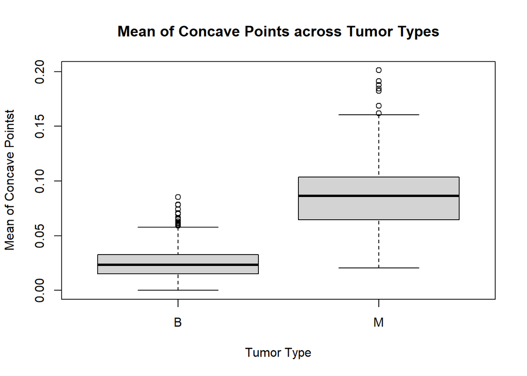

```r
# Boxplot for Mean of Concave Points
boxplot(
  concave_points_mean ~ as.factor(diagnosis),
  data = data,
  xlab = "Tumor Type",
  ylab = "Mean of Concave Pointst",
  main = "Mean of Concave Points across Tumor Types"
)
```

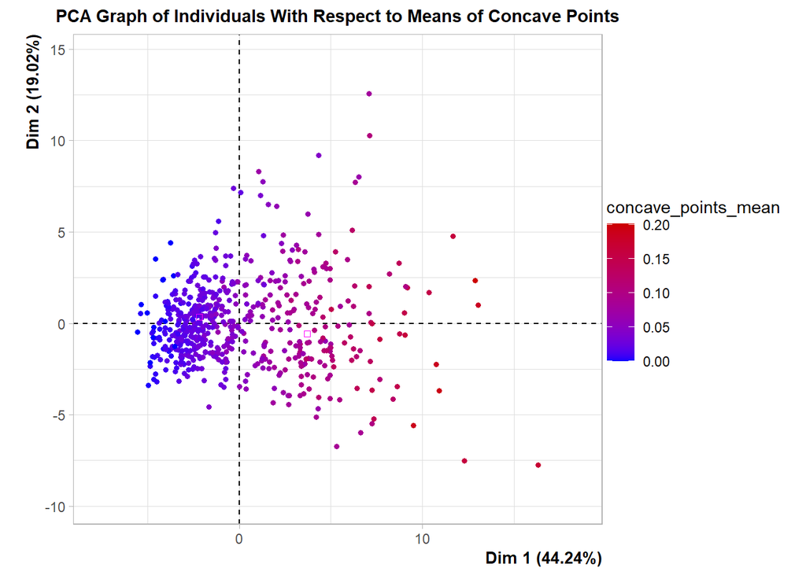

```r
plot.PCA(res.pca,
   choix = "ind",
   hab = "concave_points_mean",
   invisible = c("var"),
   cex = 1,
   autoLab = c("no"),
   title = "PCA Graph of Individuals With Respect to Means of Concave Points",
   label = c("none")
)
```

We can see that there is significant difference of mean of concave points between malignant and benign breast tumors. The mean of concave points of malignant breast tumors is much higher than that of benign ones as in the Box Plot. Recall the variable PCA plot, the mean of concave points is strongly positive correlated with Dim 1, which is also true in the PCA graph of individuals as we can see almost all malignant breast tumors are aligned to the right of Dim 1. Hence, they have higher mean of concave points. All mentions above prove that a high number of concave points usually the sign of breast cancer.

### **Hypothesis 2:** Mean of Concavity between benign and malignant tumors.

- Null Hypothesis (H0): There is no significant difference in Mean of Concavity between 2 tumor types.
- Alternative Hypothesis (H1): There is a significant difference in Mean of Concavity between 2 tumor types.

#### Test:

ANOVA for Mean of Concavity among tumor types.

```r
# ANOVA for Mean of Concavity among tumor types.
h2 <- lm(
  concavity_mean ~ as.factor(diagnosis),
  data = data
)
anova(h2)
```

|  | Df | Sum Sq | Mean Sq | F value | Pr(>F) |
| --- | --- | --- | --- | --- | --- |
| as.factor(diagnosis) | 1 | 1.744672 | 1.74467157 | 531.703 | 1.869723e-83 |
| Residuals | 566 | 1.857210 | 0.00328129 | NA | NA |

#### Interpretation:

The ANOVA test indicates a highly significant difference in Mean of Concavity among different tumor types (p = 2.2e-16 < 0.001). This suggests that Mean of Concavity vary strongly between benign and malignant tumor. Then **reject Hypothesis**.

#### Visualization:

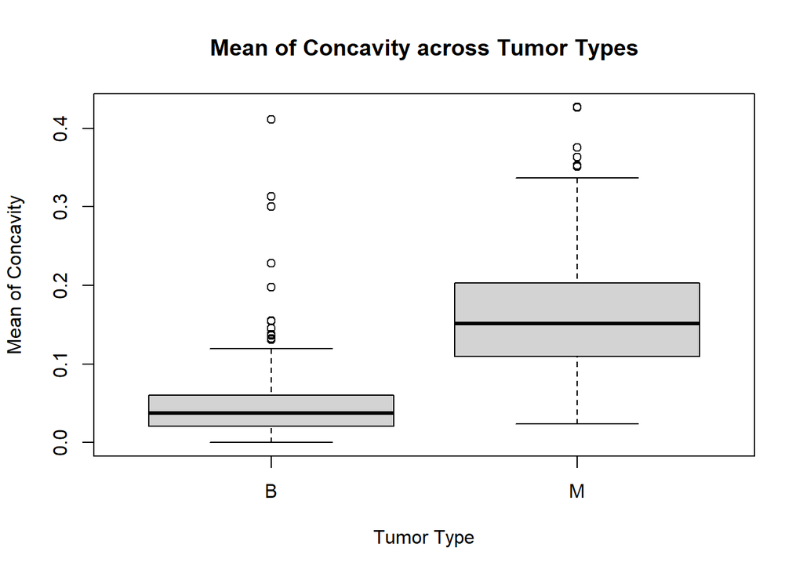

```r
# Boxplot for Mean of Concavity
boxplot(
  concavity_mean ~ as.factor(diagnosis),
  data = data,
  xlab = "Tumor Type",
  ylab = "Mean of Concavity",
  main = "Mean of Concavity across Tumor Types"
)
```

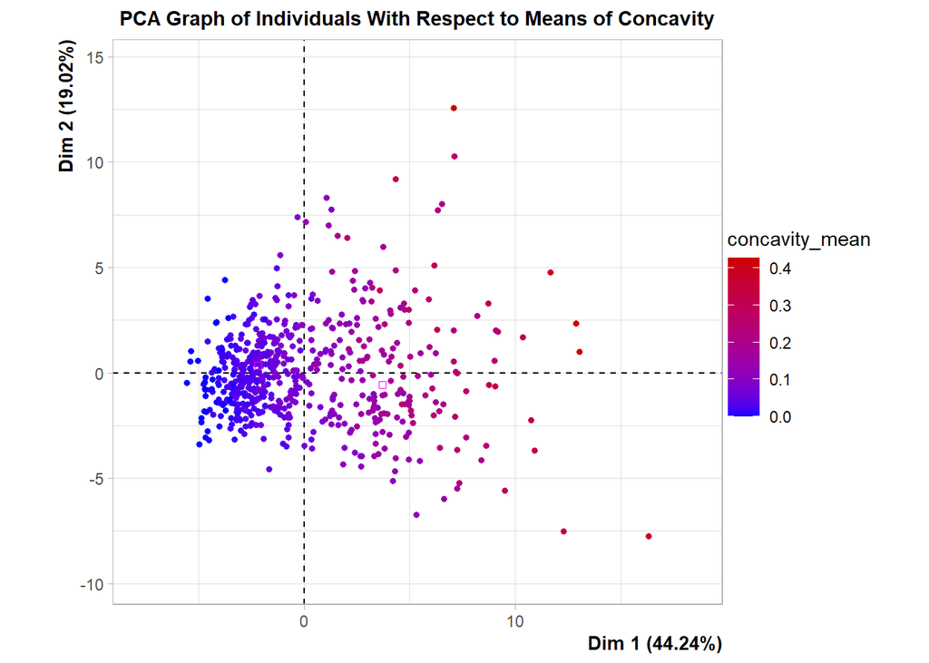

```r
plot.PCA(res.pca,
   choix = "ind",
   hab = "concavity_mean",
   invisible = c("var"),
   cex = 1,
   autoLab = c("no"),
   title = "PCA Graph of Individuals With Respect to Means of Concavity",
   label = c("none")
)
```

Just like Mean of Concave Points, the mean of concavity is quite different between malignant and benign breast tumors. The mean of concavity of malignant breast tumors is much higher than that of benign ones as in the Box Plot. Recall the variable PCA plot, the mean of concavity is also strongly positive correlated with Dim 1 similar to the mean of concave points. We can see in the PCA graph of individuals that almost all malignant breast tumors are aligned to the right of Dim 1. Therefore, the bigger size of tumor, the higher chance of a person to have breast cancer.

### **Hypothesis 3:** Worst Concave Points between benign and malignant tumors.

- Null Hypothesis (H0): There is no significant difference in Worst Concave Points between 2 tumor types.
- Alternative Hypothesis (H1): There is a significant difference in Worst Concave Points between 2 tumor types.

#### Test:

ANOVA for Worst Concave Points among tumor types.

```r
# ANOVA for Worst Concave Points among tumor types.
h3 <- lm(
  concave_points_worst ~ as.factor(diagnosis),
  data = data
)
anova(h3)
```

|  | Df | Sum Sq | Mean Sq | F value | Pr(>F) |
| --- | --- | --- | --- | --- | --- |
| as.factor(diagnosis) | 1 | 1.5379128 | 1.537912812 | 963.8455 | 2.612174e-124 |
| Residuals | 566 | 0.9031102 | 0.001595601 | NA | NA |

#### Visualization:

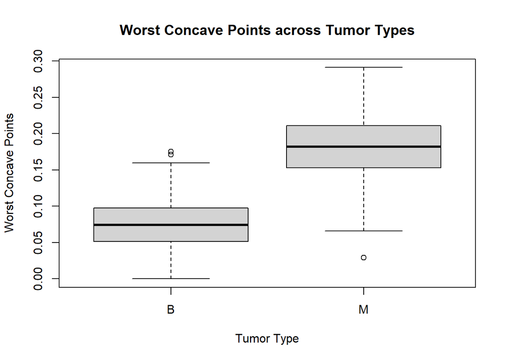

```r
# Boxplot for Worst Concave Points
boxplot(
  concave_points_worst ~ as.factor(diagnosis),
  data = data,
  xlab = "Tumor Type",
  ylab = "Worst Concave Points",
  main = "Worst Concave Points across Tumor Types"
)
```

[figure not shown]

```r
plot.PCA(res.pca,
   choix = "ind",
   hab = "concavity_worst",
   invisible = c("var"),
   cex = 1,
   autoLab = c("no"),
   title = "PCA Graph of Individuals With Respect to Worst Concave Points",
   label = c("none")
)
```

### **Hypothesis 4:** Mean of Compactness between benign and malignant tumors.

- Null Hypothesis (H0): There is no significant difference in Mean of Compactness between 2 tumor types.
- Alternative Hypothesis (H1): There is a significant difference in Mean of Compactness between 2 tumor types.

#### Test:

ANOVA for Mean of Compactness among tumor types.

```r
# ANOVA for Mean of Compactness among tumor types.
h4 <- lm(
  compactness_mean ~ as.factor(diagnosis),
  data = data
)
anova(h4)
```

|  | Df | Sum Sq | Mean Sq | F value | Pr(>F) |
| --- | --- | --- | --- | --- | --- |
| as.factor(diagnosis) | 1 | 0.5614021 | 0.561402089 | 311.779 | 6.573128e-56 |
| Residuals | 566 | 1.0191628 | 0.001800641 | NA | NA |

#### Interpretation:

The ANOVA test indicates a highly significant difference in Mean of Compactness among different tumor types (p = 2.2e-16 < 0.001). This suggests that Mean of Compactness vary strongly between benign and malignant tumor. Then **reject Hypothesis**.

#### Visualization:

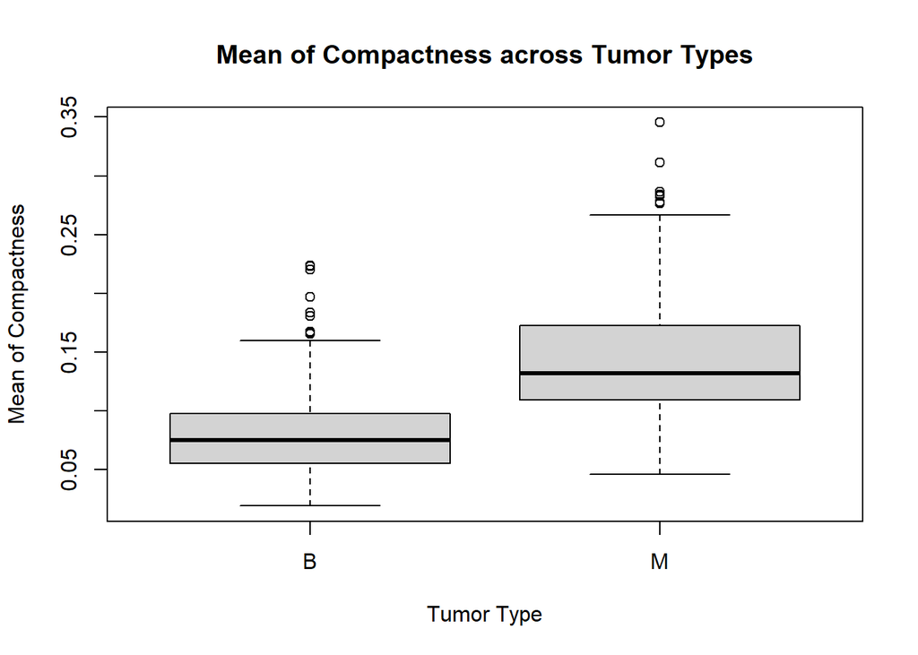

```r
# Boxplot for Mean of Compactness
boxplot(
  compactness_mean ~ as.factor(diagnosis),
  data = data,
  xlab = "Tumor Type",
  ylab = "Mean of Compactness",
  main = "Mean of Compactness across Tumor Types"
)
```

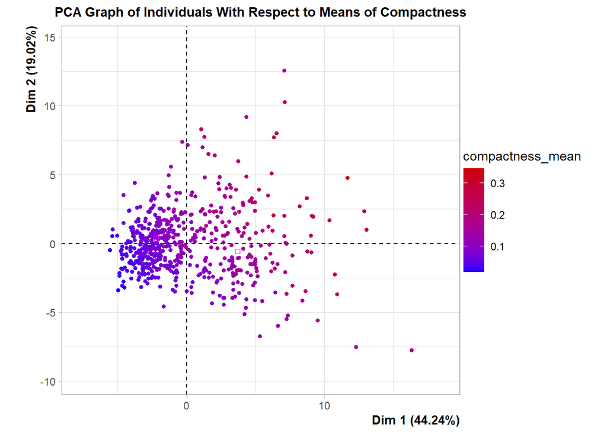

```r
plot.PCA(res.pca,
   choix = "ind",
   hab = "compactness_mean",
   invisible = c("var"),
   cex = 1,
   autoLab = c("no"),
   title = "PCA Graph of Individuals With Respect to Means of Compactness",
   label = c("none")
)
```

Here, Mean of Compactness is different between 2 type of breast tumors. The Mean of Compactness of malignant breast tumors is also higher than that of benign ones as in the Box Plot. And, the Mean of Compactness is positively correlated with Dim 1 and just like all the concavity stats above, almost all malignant breast tumors are aligned to the right of Dim 1.

### Other hypotheses on an variable between benign and malignant tumors.

Similar to the analysis above and the Dimension Description of the PCA on the dataset, we can find some other variables that are: - Significantly different between benign and malignant tumors. - Positively correlated with Dim 1 of PCA variable graph. Means that higher value correspond to higher chance of breast cancer.

These variables are: - perimeter_worst - concavity_worst - radius_worst - perimeter_mean - area_worst - area_mean

```r
h4.1 <- lm(
  perimeter_worst ~ as.factor(diagnosis),
  data = data
)
anova(h4.1)
```

|  | Df | Sum Sq | Mean Sq | F value | Pr(>F) |
| --- | --- | --- | --- | --- | --- |
| as.factor(diagnosis) | 1 | 391575.9 | 391575.9174 | 895.6542 | 1.064696e-118 |
| Residuals | 566 | 247452.6 | 437.1954 | NA | NA |

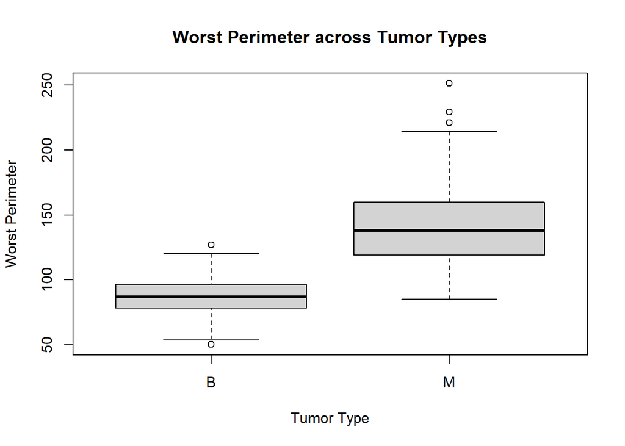

```r
# Boxplot for Worst Perimeter
boxplot(
  perimeter_worst ~ as.factor(diagnosis),
  data = data,
  xlab = "Tumor Type",
  ylab = "Worst Perimeter",
  main = "Worst Perimeter across Tumor Types"
)
```

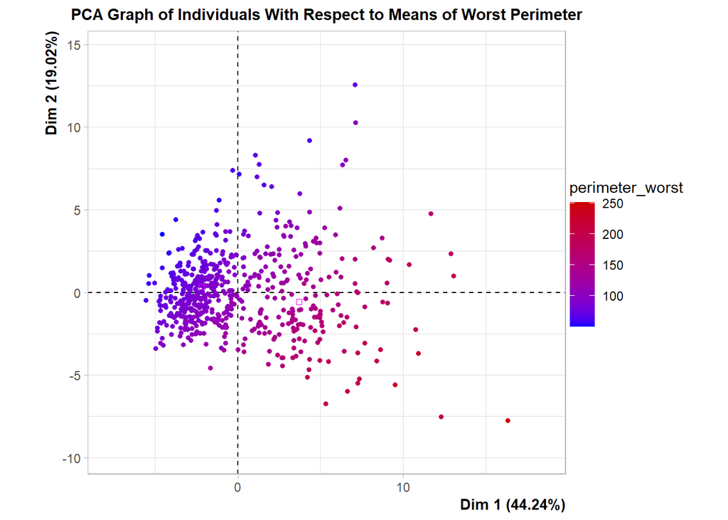

```r
plot.PCA(res.pca,
   choix = "ind",
   hab = "perimeter_worst",
   invisible = c("var"),
   cex = 1,
   autoLab = c("no"),
   title = "PCA Graph of Individuals With Respect to Means of Worst Perimeter",
   label = c("none")
)
```